# HW5

Ramtin Boustani - SUID# 05999261

# Problem 1

**Chapter 6, Exercise 1**

### (a)

Best subset selection has the samllest training RSS because of doing exhaustive search among all possible combinations

### (b)

Mostly Best subset selection because of doing exhaustive search among all possible combinations but there is a chance other methods performing better.

### (c)

#### i.

True

#### ii.

True

#### iii.

False, there is no relation between predictors chosen in backward and forward subset selection.

#### iv.

False, there is no relation between predictors chosen in backward and forward subset selection.

#### V.

False

# Problem 2

**Chapter 6, Exercise 3**

### (a)

4. steadily decrease.  
   By increasing s, coefficients are less restrictive and they have more variance and less bias and model will have less training RSS.

### (b)

2. decrease intially and eventually U shape. General pattern, model become more and more flexible and up to some point and then overfitting issue causes increase test RSS.

### (c)

3. steadily increase, the same behaviour mentioned above.

### (d)

4. steadily decrease, by increasing s we have more and more variance and less and less bias.

### (e)

# Problem 3

**Chapter 6, Exercise 8**

### (a)

```r
set.seed(1)
X = rnorm(100)
eps = rnorm(100)
```

### (b)

All non-zero coefficients equal to 0.5

```r
beta0 = 0.5
beta1 = 0.5
beta2 = 0.5
beta3 = 0.5
Y = beta0 + beta1 * X + beta2 * X^2 + beta3 * X^3 + eps
```

### (c)

#### Best subset selection

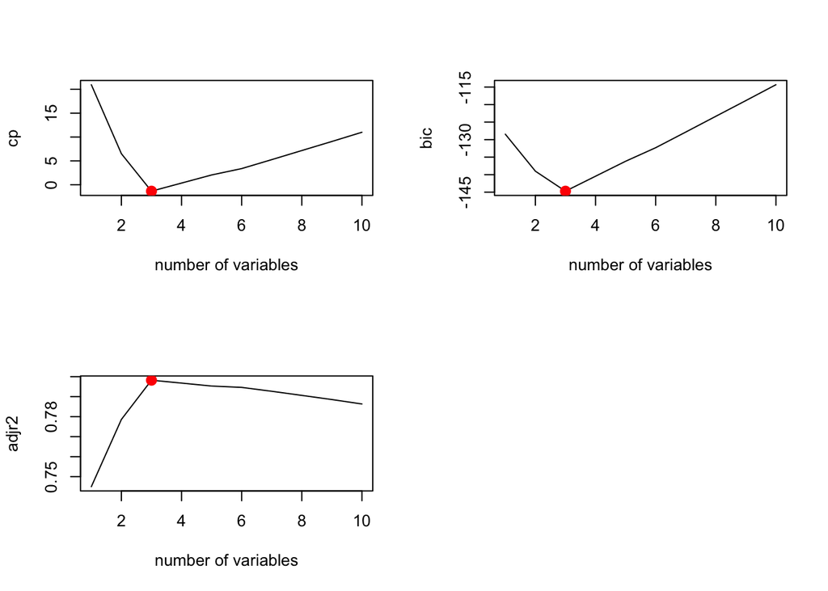

```r
library(leaps)
data = data.frame( Y=Y, poly(X, 10, raw = T))
regfit.data = data
regfit.full = regsubsets(Y ~ . , data = regfit.data, nvmax = 10, method = "exhaustive")
regfit.summary = summary(regfit.full)
par(mfrow = c(2,2))
plot(regfit.summary$cp, xlab = "number of variables", ylab = "cp", type="l")
points(which.min(regfit.summary$cp), regfit.summary$cp[which.min(regfit.summary$cp)], col="red", cex=2, pch=20)
plot(regfit.summary$bic, xlab = "number of variables", ylab = "bic", type="l")
points(which.min(regfit.summary$bic), regfit.summary$bic[which.min(regfit.summary$bic)],col="red", cex=2, pch=20)
plot(regfit.summary$adjr2, xlab="number of variables", ylab = "adjr2", type="l")
points(which.max(regfit.summary$adjr2), regfit.summary$adjr2[which.max(regfit.summary$adjr2)],col = "red", cex = 2, pch = 20)
```

```r
which.max(regfit.summary$adjr2)
```

```
## [1] 3
```

```r
coef(regfit.full, id= which.max(regfit.summary$adjr2))
```

```
## (Intercept)          X1          X2          X5
##  0.57219472  0.94514720  0.34323764  0.09022577
```

Insted of X3, X5 has chosen.  
beta0 is a good estimate but coefficients of X1, X2 and X5 is not close 0.5!

### (d)

#### Forward subset selection

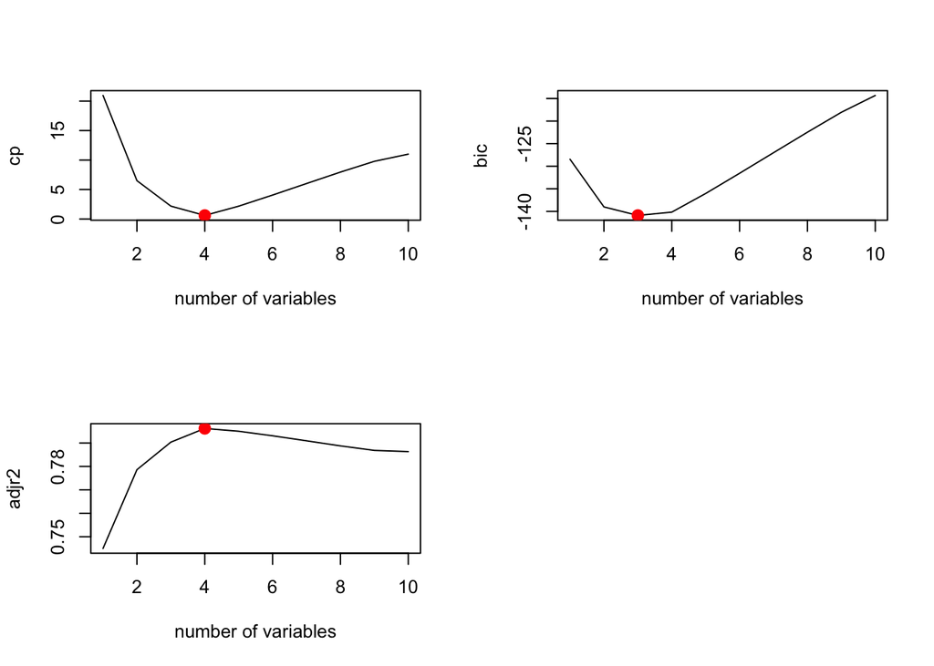

```r
regfit.fwd = regsubsets(Y ~ . , data = regfit.data, nvmax = 10, method = "forward")
regfit.summary = summary(regfit.fwd)
par(mfrow = c(2,2))
plot(regfit.summary$cp, xlab = "number of variables", ylab = "cp", type="l")
points(which.min(regfit.summary$cp), regfit.summary$cp[which.min(regfit.summary$cp)], col="red", cex=2, pch=20)
plot(regfit.summary$bic, xlab = "number of variables", ylab = "bic", type="l")
points(which.min(regfit.summary$bic), regfit.summary$bic[which.min(regfit.summary$bic)],col="red", cex=2, pch=20)
plot(regfit.summary$adjr2, xlab="number of variables", ylab = "adjr2", type="l")
points(which.max(regfit.summary$adjr2), regfit.summary$adjr2[which.max(regfit.summary$adjr2)],col = "red", cex = 2, pch = 20)
```

```r
which.max(regfit.summary$adjr2)
```

```
## [1] 4
```

```r
coef(regfit.fwd, id= which.max(regfit.summary$adjr2))
```

```
## (Intercept)          X1          X2          X3          X5
##  0.57200775  0.88745596  0.34575641  0.05797426  0.08072292
```

#### Backward subset selection

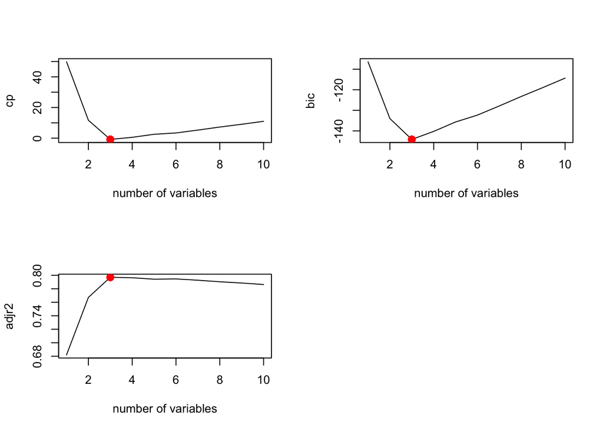

```r
regfit.bwd = regsubsets(Y ~ . , data = regfit.data, nvmax = 10, method = "backward")
regfit.summary = summary(regfit.bwd)
par(mfrow = c(2,2))
plot(regfit.summary$cp, xlab = "number of variables", ylab = "cp", type="l")
points(which.min(regfit.summary$cp), regfit.summary$cp[which.min(regfit.summary$cp)], col="red", cex=2, pch=20)
plot(regfit.summary$bic, xlab = "number of variables", ylab = "bic", type="l")
points(which.min(regfit.summary$bic), regfit.summary$bic[which.min(regfit.summary$bic)],col="red", cex=2, pch=20)
plot(regfit.summary$adjr2, xlab="number of variables", ylab = "adjr2", type="l")
points(which.max(regfit.summary$adjr2), regfit.summary$adjr2[which.max(regfit.summary$adjr2)],col = "red", cex = 2, pch = 20)
```

```r
which.max(regfit.summary$adjr2)
```

```
## [1] 3
```

```r
coef(regfit.bwd, id= which.max(regfit.summary$adjr2))
```

```
## (Intercept)          X1          X4          X5
##  0.69884006  0.98672610  0.07758979  0.08472786
```

Best subset selection chosen 3 variables (Intercept=0.57, X1=0.94, X2=0.34, X5=0.09)  
Forward subset selection chosen 4 variables (Intercept=0.57, X1= 0.88, X2=0.34, X3=0.05, X5=0.08)  
Backward subset selection chosen 3 variables (Intercept=0.69, X1=0.98, X4=0.07, X5=0.08)

### (e)

```r
library(glmnet)
xmat = model.matrix(Y ~ poly(X, 10, raw = T), data = data)[,-1]
mod.lasso = cv.glmnet(xmat, Y, alpha=1)
best.lamda = mod.lasso$lambda.min
best.lamda
```

```
## [1] 0.05272586
```

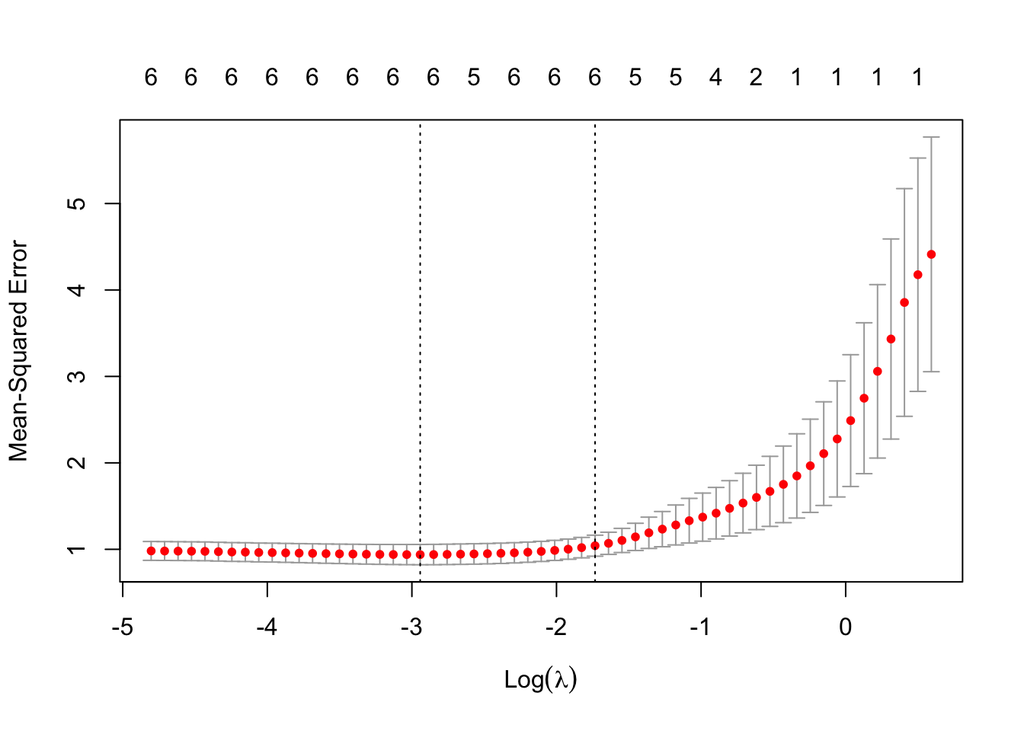

```r
plot(mod.lasso)
```

Based on the best lamda predicating using lasso

```r
fit.lasso = glmnet(xmat, Y, alpha=1)
predict(fit.lasso, s=best.lamda, type = "coefficients" )
```

```
## 11 x 1 sparse Matrix of class "dgCMatrix"
##                                   1
## (Intercept)            0.6620354260
## poly(X, 10, raw = T)1  0.7553408606
## poly(X, 10, raw = T)2  0.1503593044
## poly(X, 10, raw = T)3  0.1743999059
## poly(X, 10, raw = T)4  0.0391080323
## poly(X, 10, raw = T)5  0.0567537978
## poly(X, 10, raw = T)6  0.0002078909
## poly(X, 10, raw = T)7  .
## poly(X, 10, raw = T)8  .
## poly(X, 10, raw = T)9  .
## poly(X, 10, raw = T)10 .
```

lasso picks 6 variables which X1 has the most weight and X4, X5 and X6 have small wight

### (f)

All non-zero coefficients equal to 0.5

#### Lasso

```r
beta7= 0.5
Y = beta0 + beta7 * X^7 + eps
data = data.frame( Y=Y, poly(X, 10, raw = T))
xmat = model.matrix(Y ~ poly(X, 10, raw = T), data = data)[,-1]
mod.lasso = cv.glmnet(xmat, Y ,alpha=1)
best.lamda = mod.lasso$lambda.min
fit.lasso = glmnet(xmat, Y, alpha = 1)
predict(fit.lasso, s=best.lamda, type = "coefficients" )
```

```
## 11 x 1 sparse Matrix of class "dgCMatrix"
##                                   1
## (Intercept)            0.4714183710
## poly(X, 10, raw = T)1  .
## poly(X, 10, raw = T)2  .
## poly(X, 10, raw = T)3  .
## poly(X, 10, raw = T)4  .
## poly(X, 10, raw = T)5  .
## poly(X, 10, raw = T)6  .
## poly(X, 10, raw = T)7  0.4936609079
## poly(X, 10, raw = T)8  .
## poly(X, 10, raw = T)9  0.0007375787
## poly(X, 10, raw = T)10 .
```

#### best subset selection

```r
regfit.full = regsubsets( Y~. , data=data, method = "exhaustive", nvmax = 10)
regfit.summary = summary(regfit.full)
coef(regfit.full, id = which.min(regfit.summary$cp) )
```

```
## (Intercept)          X2          X7
##   0.5704904  -0.1417084   0.5015552
```

# Problem 4

**Chapter 6, Exercise 9**

### (a)

```r
library(ISLR)
set.seed(1)
n = dim(College)[1]
train.size = n/2
train = sample( 1:n, size = train.size)
College.train = College[train, ]
College.test = College[-train, ]
```

### (b)

```r
lm.fit = lm(Apps ~ ., data=College.train)
lm.predict = predict(lm.fit, College.test)
lm.test = mean((College.test[,"Apps"]-lm.predict)^2)
lm.test
```

```
## [1] 1135758
```

### (c)

```r
train.xmat = model.matrix(Apps~. , data=College.train )
test.xmat = model.matrix(Apps~. , data=College.test )
train.y = College.train[,"Apps"]
test.y = College.test[,"Apps"]
mod.ridge = cv.glmnet(x = train.xmat, y = train.y, alpha=0)
best.lamda = mod.ridge$lambda.min
pred.ridge = predict(mod.ridge, s=best.lamda, newx = test.xmat)
ridge.test = mean((test.y - pred.ridge)^2)
ridge.test
```

```
## [1] 976261.5
```

### (d)

```r
mod.lasso = cv.glmnet(x = train.xmat, y = train.y, alpha=1)
best.lamda = mod.lasso$lambda.min
pred.lasso = predict(mod.lasso, s=best.lamda, newx = test.xmat)
lasso.test = mean((test.y - pred.lasso)^2)
lasso.test
```

```
## [1] 1115901
```

Test error for lasso is higher than ridge regression

```r
mod.lasso = glmnet( x= model.matrix( Apps~. , data =College), y=College[,"Apps"], alpha = 1)
predict(mod.lasso, s=best.lamda , type="coefficients")
```

```
## 19 x 1 sparse Matrix of class "dgCMatrix"
##                         1
## (Intercept) -471.39372069
## (Intercept)    .
## PrivateYes  -491.04485135
## Accept         1.57033288
## Enroll        -0.75961467
## Top10perc     48.14698891
## Top25perc    -12.84690694
## F.Undergrad    0.04149116
## P.Undergrad    0.04438973
## Outstate      -0.08328388
## Room.Board     0.14943472
## Books          0.01532293
## Personal       0.02909954
## PhD           -8.39597537
## Terminal      -3.26800340
## S.F.Ratio     14.59298267
## perc.alumni   -0.04404771
## Expend         0.07712632
## Grad.Rate      8.28950241
```

PrivateYes, Accept, Top10perc, Top25perc, PhD, Terminal, S.F.Ratio, Grad.Rate have high weight  
F.Undergrad, P.Undergrad, Books, Personal, perc.alumni have very low weight

### (e)

```r
library(pls)
```

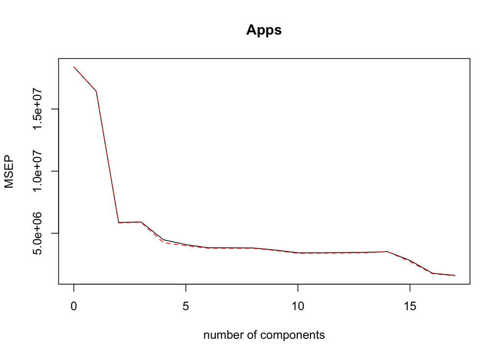

```r
fit.pcr = pcr( Apps~., data= College.train, scale=TRUE, validation="CV" )
validationplot(fit.pcr, val.type="MSEP")
```

```r
pcr.pred = predict(fit.pcr, College.test, ncomp=10)
pcr.test = mean((test.y - pcr.pred)^2)
pcr.test
```

```
## [1] 1723100
```

Test error for PCR is higger than lasso

### (f)

```r
pls.fit <- plsr(Apps ~ ., data = College.train, scale = TRUE, validation = "CV")
pls.pred <- predict(pls.fit, College.test, ncomp = 10)
pls.test = mean((pls.pred - test.y)^2)
pls.test
```

```
## [1] 1131661
```

Test error is lower than PCR

### (g)

R-square

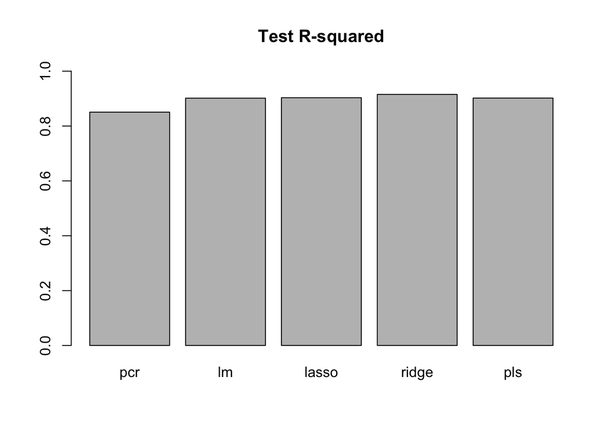

```r
test.avg <- mean(College.test$Apps)
tss =  mean((test.y-test.avg)^2)
pcr.r2 = 1 - pcr.test/tss
lm.r2 = 1 - lm.test/tss
lasso.r2 = 1 - lasso.test/tss
ridge.r2 = 1 - ridge.test/tss
pls.r2 = 1 - pls.test/tss
barplot(c(pcr.r2, lm.r2, lasso.r2, ridge.r2, pls.r2), names.arg = c("pcr", "lm", "lasso", "ridge", "pls"), main="Test R-squared" , ylim = 0:1)
```

# Problem 5

**Chapter 6, Exercise 11**

### (a)

```r
library(MASS)
set.seed(1)
```

#### best subset selection

```r
#implement predict for best subset
predict.regsubsets = function(object, newdata, id, ...) {
    form = as.formula(object$call[[2]])
    mat = model.matrix(form, newdata)
    coefi = coef(object, id = id)
    mat[, names(coefi)] %*% coefi
}

#using 10 fold corss validation
k=10
p = ncol(Boston) - 1
folds = sample(rep(1:k, length = nrow(Boston)))
cv.errors = matrix(NA, k, p)
for (i in 1:k) {
    best.fit = regsubsets(crim ~ ., data = Boston[folds != i, ], nvmax = p)
    for (j in 1:p) {
        pred = predict(best.fit, Boston[folds == i, ], id = j)
        cv.errors[i, j] = mean((Boston$crim[folds == i] - pred)^2)
    }
}
mse.cv = apply(cv.errors, 2, mean)
which.min(mse.cv)
```

```
## [1] 9
```

```r
mse.cv[which.min(mse.cv)]
```

```
## [1] 42.81453
```

#### Lasso

```r
x = model.matrix( crim ~ ., data = Boston)[,-1]
y = Boston[,1]
cv.lasso = cv.glmnet(x, y, alpha=1, type.measure = "mse")
cv.lasso
```

```
##
## Call:  cv.glmnet(x = x, y = y, type.measure = "mse", alpha = 1)
##
## Measure: Mean-Squared Error
##
##     Lambda Measure    SE Nonzero
## min  0.207   44.84 18.13       7
## 1se  4.066   62.75 23.76       1
```

#### Ridge

```r
x = model.matrix( crim ~ ., data = Boston)[,-1]
y = Boston[,1]
cv.ridge = cv.glmnet(x, y, alpha=0, type.measure = "mse")
cv.ridge
```

```
##
## Call:  cv.glmnet(x = x, y = y, type.measure = "mse", alpha = 0)
##
## Measure: Mean-Squared Error
##
##     Lambda Measure    SE Nonzero
## min   0.54   43.33 15.55      13
## 1se  81.70   58.82 19.92      13
```

#### PCR

```r
fit.pcr = pcr( crim ~., data=Boston, scale=TRUE, validation="CV")
#summary(fit.pcr)
MSEP(fit.pcr)
```

```
##        (Intercept)  1 comps  2 comps  3 comps  4 comps  5 comps  6 comps
## CV           74.13    51.48    51.55    45.21    45.31    45.25    45.25
## adjCV        74.13    51.46    51.54    45.17    45.22    45.22    45.21
##        7 comps  8 comps  9 comps  10 comps  11 comps  12 comps  13 comps
## CV       45.19    43.74    43.79     43.66     43.53     42.94      42.1
## adjCV    45.13    43.68    43.73     43.58     43.46     42.85      42.0
```

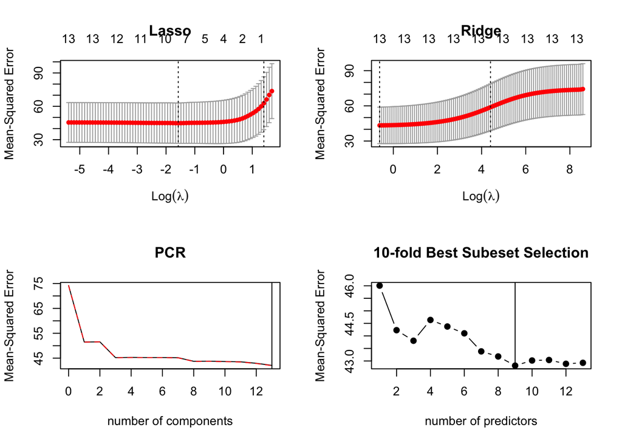

```r
par(mfrow = c(2,2))
plot(cv.lasso , main="Lasso" )
plot(cv.ridge, main = "Ridge")
validationplot(fit.pcr, val.type="MSEP" ,ylab = "Mean-Squared Error", main="PCR")
abline(v=13)
plot(mse.cv, pch = 19, type = "b",  ylab = "Mean-Squared Error", xlab = "number of predictors", main="10-fold Best Subeset Selection")
abline(v=which.min(mse.cv))
```